# Logistic Regression

Author

Dr Hazlienor Mohd Hatta

Published

April 15, 2024

# Background

## Problem statement

Diabetes Mellitus (DM) is becoming more common, and early detection of individuals at high risk is crucial for better prevention and management. Various factors like age, gender, BMI, blood pressure, and blood sugar levels may influence the likelihood of developing DM. This study aims to use a **predictive model** to understand which factors are most strongly associated with DM and to help **identify individuals at risk** based on these factors.

## Objective

To examine the key factors that contribute to the likelihood of developing Diabetes Mellitus.

## Dataset description

This dataset consists of 3,820 individuals and is primarily focused on identifying potential predictors of Diabetes Mellitus (DM), with the variable **dmdx** (Diabetes diagnosis) serving as the outcome variable. The dataset includes various demographic, anthropometric, and clinical measurements to evaluate the factors that may influence the presence or absence of DM.

| **Variable** | **Description** |
| --- | --- |
| `codesub` | Unique individual ID |
| `age` | Age in years |
| `dmdx` | Ever diagnosed with diabetes (0 = No, 1 = Yes) |
| `height` | Height in meters |
| `weight` | Weight in kg |
| `waist` | Waist circumference in cm |
| `hip` | Hip circumference in cm |
| `msbpr` | Mean systolic blood pressure (right arm, mmHg) |
| `mdbpr` | Mean diastolic blood pressure (right arm, mmHg) |
| `hba1c` | HbA1c level (mmol/l) |
| `fbs` | Fasting blood sugar (mmol/l) |
| `mogtt2h` | 2-hour post MOGTT glucose (mmol/l) |
| `totchol` | Total cholesterol (mmol/l) |
| `ftrigliz` | Fasting triglycerides (mmol/l) |
| `hdl` | HDL cholesterol (mmol/l) |
| `ldl` | LDL cholesterol (mmol/l) |
| `gender` | Gender (0 = Female, 1 = Male) |
| `crural` | Residence area (0 = Urban, 1 = Rural) |
| `bmi` | Body Mass Index (kg/m²) |

## Assumptions

- The outcome is a binary or dichotomous variable (for binary logistic regression)
- Observations independent of each other
- Little or no multicollinearity among the independent variables
- Linearity in logit - linearity of independent variables and log odds of the dependent variable
- There is no influential values (extreme values or outliers) in the continuous predictors

# Workflow

1. Prepare environment
2. Prepare data(read-view-transform-describe-explore)
3. Estimate: univariate analysis & Multivariate analysis - fitting the model (include interaction and confounding)
4. Inference
5. Prediction
6. Model assessment: Pearson & H-L, classification table, ROC curve
7. Presentation

## Prepare environment

**Install required packages**

remove # when you run this code

```r
#install.packages(setdiff(c("tidyverse", "broom", "haven", "gtsummary", "corrplot",  "mfp", "pROC", "car", "lattice", "caret", "generalhoslem"), rownames(installed.packages())))
```

**Load required packages**

```r
library(tidyverse) #data wrangling, visualization, and analysis
library(broom) #tidy data frames for easier summary
library(haven) #Reads data from SPSS, Stata, and SAS — importing .sav, .dta
library(gtsummary) #summary tables for data and regression models
library(corrplot) # visualize correlation
library(mfp) #electing transformations
library(pROC) #Diagnostic tools for logistic regression
library(car) # check for multicollinearity
library(lattice) # check model fitness
library(caret) # check model fitness
library(generalhoslem) # check model fitness
```

## Load data

```r
diabetes <-
  read_dta('diabetes.dta')
```

## Data Exploration and Wrangling

```r
str(diabetes)
```

```
tibble [3,820 × 19] (S3: tbl_df/tbl/data.frame)
 $ codesub : chr [1:3820] "R-S615112" "MAA615089" "M-M616372" "MFM615361" ...
  ..- attr(*, "label")= chr "individual unique identifier"
  ..- attr(*, "format.stata")= chr "%15s"
 $ age     : num [1:3820] 70 20 29 25 37 43 26 28 48 20 ...
  ..- attr(*, "label")= chr "reported age (years)"
  ..- attr(*, "format.stata")= chr "%3.0f"
 $ dmdx    : dbl+lbl [1:3820] 0, 0, 0, 0, 0, 0, 0, 0, 0, 0, 0, 0, 0, 0, 0, 0, 0, 0,...
   ..@ label       : chr "ever been diagnosed with diabetes mellitus?"
   ..@ format.stata: chr "%3.0f"
   ..@ labels      : Named num [1:2] 0 1
   .. ..- attr(*, "names")= chr [1:2] "no" "yes"
 $ height  : num [1:3820] 1.54 1.74 1.54 1.6 1.44 1.46 1.47 1.61 1.68 1.55 ...
  ..- attr(*, "label")= chr "height (meter)"
  ..- attr(*, "format.stata")= chr "%9.2f"
 $ weight  : num [1:3820] 40 54.6 37 48.4 44.5 45.5 48 40 48.4 41 ...
  ..- attr(*, "label")= chr "weight (kg)"
  ..- attr(*, "format.stata")= chr "%9.1f"
 $ waist   : num [1:3820] 76 83 83 83.5 85 90 91 80 82 79 ...
  ..- attr(*, "label")= chr "waist circum (cm)"
  ..- attr(*, "format.stata")= chr "%9.1f"
 $ hip     : num [1:3820] 61 62 63 64 64 64 64 64 65 66 ...
  ..- attr(*, "label")= chr "hip circum (cm)"
  ..- attr(*, "format.stata")= chr "%9.1f"
 $ msbpr   : num [1:3820] 135 105 91 117 102 124 120 85 112 108 ...
  ..- attr(*, "label")= chr "mean SBP for right arm (mmHG)"
  ..- attr(*, "format.stata")= chr "%9.2f"
 $ mdbpr   : num [1:3820] 80 58 60 68.5 78 65.5 77 60 74 52 ...
  ..- attr(*, "label")= chr "mean DBP for right arm (mmHG)"
  ..- attr(*, "format.stata")= chr "%9.2f"
 $ hba1c   : num [1:3820] 5.2 5.3 4.8 4.8 5.1 5.1 4.8 4.9 5.6 4.2 ...
  ..- attr(*, "label")= chr "mmol/l"
  ..- attr(*, "format.stata")= chr "%9.2f"
 $ fbs     : num [1:3820] 3.99 4.26 4.94 4.6 4.6 4.42 3.82 4.4 4.8 3.68 ...
  ..- attr(*, "label")= chr "fasting blood sugar (mmol/l)"
  ..- attr(*, "format.stata")= chr "%9.2f"
 $ mogtt2h : num [1:3820] 3.22 6.49 5.15 3.85 7.71 5.65 5.88 4.89 4.29 2.59 ...
  ..- attr(*, "label")= chr "MOGTT 2 hour post (mmol/l)"
  ..- attr(*, "format.stata")= chr "%9.2f"
 $ totchol : num [1:3820] 5.43 5.13 5.55 4.01 5.21 6.19 4.33 5.84 6.14 6.02 ...
```

[output cut: 9 more lines]

```
  ..- attr(*, "label")= chr "low-density lipoprotein (mmol/l)"
  ..- attr(*, "format.stata")= chr "%9.2f"
 $ gender  : dbl+lbl [1:3820] 0, 1, 0, 1, 0, 0, 0, 0, 1, 0, 0, 0, 0, 0, 0, 0, 0, 0,...
   ..@ label       : chr "gender"
   ..@ format.stata: chr "%9.0g"
   ..@ labels      : Named num [1:2] 0 1
   .. ..- attr(*, "names")= chr [1:2] "female" "male"
 $ crural  : dbl+lbl [1:3820] 1, 1, 1, 1, 1, 1, 1, 1, 1, 1, 1, 1, 0, 1, 0, 1, 1, 0,...
   ..@ label       : chr "rural=1 urban=0"
   ..@ format.stata: chr "%9.0g"
   ..@ labels      : Named num [1:2] 0 1
   .. ..- attr(*, "names")= chr [1:2] "urban" "rural"
 $ bmi     : num [1:3820] 16.9 18 15.6 18.9 21.5 ...
  ..- attr(*, "label")= chr "weight (kg)"
  ..- attr(*, "format.stata")= chr "%9.1f"
```

bmi is labelled as weight. lets change the label

```r
attr(diabetes$bmi, "label") <- "BMI"
```

convert all categorical variable as factor

```r
diabetes <-
  diabetes %>%
  mutate(across(where(is.labelled), as_factor))
glimpse(diabetes)
```

```
Rows: 3,820
Columns: 19
$ codesub  <chr> "R-S615112", "MAA615089", "M-M616372", "MFM615361", "R-A61578…
$ age      <dbl> 70, 20, 29, 25, 37, 43, 26, 28, 48, 20, 56, 55, 26, 39, 18, 2…
$ dmdx     <fct> no, no, no, no, no, no, no, no, no, no, no, no, no, no, no, n…
$ height   <dbl> 1.54, 1.74, 1.54, 1.60, 1.44, 1.46, 1.47, 1.61, 1.68, 1.55, 1…
$ weight   <dbl> 40.0, 54.6, 37.0, 48.4, 44.5, 45.5, 48.0, 40.0, 48.4, 41.0, 5…
$ waist    <dbl> 76.0, 83.0, 83.0, 83.5, 85.0, 90.0, 91.0, 80.0, 82.0, 79.0, 9…
$ hip      <dbl> 61, 62, 63, 64, 64, 64, 64, 64, 65, 66, 67, 67, 67, 67, 67, 6…
$ msbpr    <dbl> 135.0, 105.0, 91.0, 117.0, 102.0, 124.0, 120.0, 85.0, 112.0, …
$ mdbpr    <dbl> 80.0, 58.0, 60.0, 68.5, 78.0, 65.5, 77.0, 60.0, 74.0, 52.0, 1…
$ hba1c    <dbl> 5.2, 5.3, 4.8, 4.8, 5.1, 5.1, 4.8, 4.9, 5.6, 4.2, 5.1, 5.3, 4…
$ fbs      <dbl> 3.99, 4.26, 4.94, 4.60, 4.60, 4.42, 3.82, 4.40, 4.80, 3.68, 6…
$ mogtt2h  <dbl> 3.22, 6.49, 5.15, 3.85, 7.71, 5.65, 5.88, 4.89, 4.29, 2.59, 7…
$ totchol  <dbl> 5.43, 5.13, 5.55, 4.01, 5.21, 6.19, 4.33, 5.84, 6.14, 6.02, 6…
$ ftrigliz <dbl> 1.06, 1.17, 0.72, 1.12, 0.78, 1.11, 0.73, 0.79, 1.63, 0.81, 1…
$ hdl      <dbl> 1.65, 1.59, 2.24, 1.21, 1.43, 2.18, 0.98, 1.81, 1.63, 1.47, 1…
$ ldl      <dbl> 2.69, 2.79, 2.55, 1.83, 2.40, 2.93, 1.82, 3.43, 3.71, 2.77, 3…
$ gender   <fct> female, male, female, male, female, female, female, female, m…
$ crural   <fct> rural, rural, rural, rural, rural, rural, rural, rural, rural…
$ bmi      <dbl> 16.86625, 18.03409, 15.60128, 18.90625, 21.46026, 21.34547, 2…
```

summary of all variables

```r
summary(diabetes)
```

```
   codesub               age         dmdx          height          weight
 Length:3820        Min.   :18.00   no :3363   Min.   :1.290   Min.   : 30.00
 Class :character   1st Qu.:38.00   yes: 457   1st Qu.:1.510   1st Qu.: 53.60
 Mode  :character   Median :48.00              Median :1.560   Median : 62.00
                    Mean   :47.92              Mean   :1.568   Mean   : 63.25
                    3rd Qu.:58.00              3rd Qu.:1.630   3rd Qu.: 71.50
                    Max.   :89.00              Max.   :1.960   Max.   :128.50

     waist             hip             msbpr           mdbpr
 Min.   : 50.80   Min.   : 61.00   Min.   : 76.5   Min.   : 41.50
 1st Qu.: 77.00   1st Qu.: 91.00   1st Qu.:117.0   1st Qu.: 70.00
 Median : 86.00   Median : 97.00   Median :129.8   Median : 77.50
 Mean   : 85.92   Mean   : 97.51   Mean   :132.7   Mean   : 77.98
 3rd Qu.: 94.40   3rd Qu.:104.00   3rd Qu.:146.0   3rd Qu.: 85.12
 Max.   :134.00   Max.   :148.00   Max.   :210.0   Max.   :123.00
 NA's   :2        NA's   :2
     hba1c             fbs            mogtt2h          totchol
 Min.   : 3.800   Min.   : 2.500   Min.   : 0.170   Min.   : 2.13
 1st Qu.: 5.100   1st Qu.: 4.460   1st Qu.: 5.210   1st Qu.: 4.96
 Median : 5.400   Median : 5.160   Median : 6.610   Median : 5.70
 Mean   : 5.782   Mean   : 5.612   Mean   : 7.206   Mean   : 5.77
 3rd Qu.: 5.800   3rd Qu.: 5.960   3rd Qu.: 8.350   3rd Qu.: 6.50
 Max.   :15.000   Max.   :28.010   Max.   :29.830   Max.   :14.91
                  NA's   :3        NA's   :420
    ftrigliz          hdl             ldl           gender       crural
 Min.   :0.180   Min.   :0.120   Min.   :0.510   female:2497   urban:2001
 1st Qu.:0.920   1st Qu.:1.110   1st Qu.:2.800   male  :1323   rural:1819
 Median :1.250   Median :1.330   Median :3.460
 Mean   :1.511   Mean   :1.355   Mean   :3.543
 3rd Qu.:1.752   3rd Qu.:1.550   3rd Qu.:4.220
 Max.   :7.990   Max.   :4.430   Max.   :9.420

      bmi
 Min.   : 9.241
 1st Qu.:22.176
 Median :25.283
 Mean   :25.688
 3rd Qu.:28.674
 Max.   :42.374
```

Lets visualize the distribution of some of the variables between diabetic and non-diabetic patient

DM by age

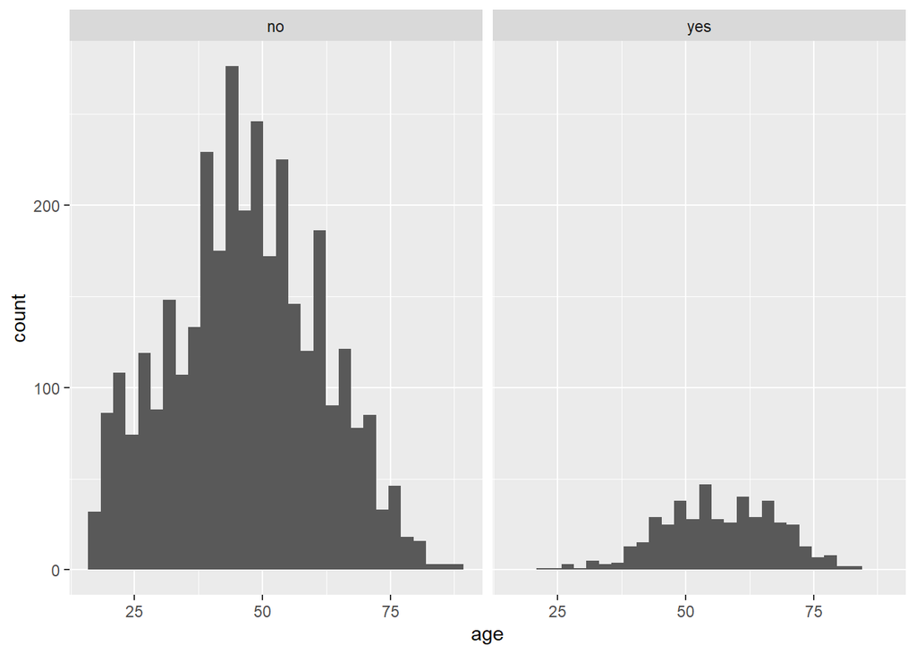

```r
diabetes |>
  ggplot(aes(age)) +
  geom_histogram() +
  facet_grid(. ~ dmdx)
```

BMI by DM

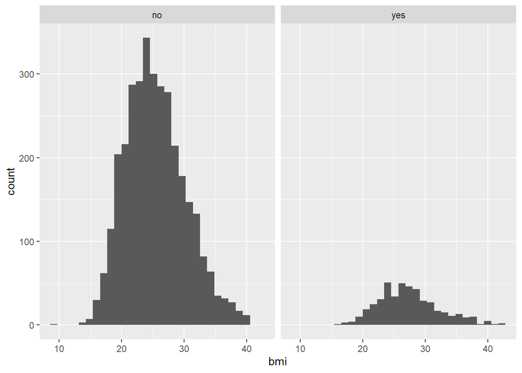

```r
diabetes |>
  ggplot(aes(bmi)) +
  geom_histogram() +
  facet_grid(. ~ dmdx)
```

DM by gender

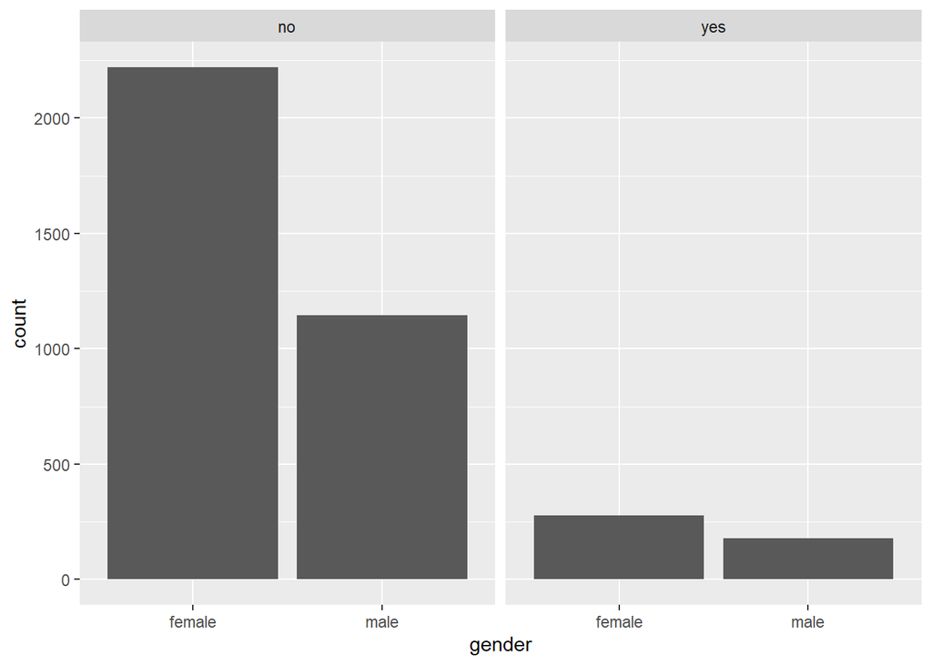

```r
diabetes |>
  ggplot(aes(gender)) +
  geom_bar() +
  facet_grid(. ~ dmdx)
```

lets check for **correlated variable**

```r
corr <- diabetes %>% dplyr::select(age, msbpr, mdbpr, fbs, mogtt2h,
                    totchol, ftrigliz, hdl) %>%
                    cor(use = 'complete.obs')
corr
```

```
               age         msbpr       mdbpr        fbs    mogtt2h   totchol
age      1.0000000  0.4620798206  0.23285555 0.19987906 0.23262123 0.3197574
msbpr    0.4620798  1.0000000000  0.70590712 0.18927229 0.24627112 0.2294469
mdbpr    0.2328556  0.7059071218  1.00000000 0.11591985 0.22761075 0.1699067
fbs      0.1998791  0.1892722892  0.11591985 1.00000000 0.58038766 0.1510847
mogtt2h  0.2326212  0.2462711155  0.22761075 0.58038766 1.00000000 0.1758102
totchol  0.3197574  0.2294468569  0.16990668 0.15108470 0.17581025 1.0000000
ftrigliz 0.1344983  0.1982708510  0.20160139 0.20117235 0.22259611 0.2622780
hdl      0.1550559 -0.0007760886 -0.06934124 0.02614275 0.02397262 0.2977744
           ftrigliz           hdl
age       0.1344983  0.1550558640
msbpr     0.1982709 -0.0007760886
mdbpr     0.2016014 -0.0693412366
fbs       0.2011723  0.0261427482
mogtt2h   0.2225961  0.0239726230
totchol   0.2622780  0.2977743622
ftrigliz  1.0000000 -0.1965275908
hdl      -0.1965276  1.0000000000
```

or, better visualize the correlation

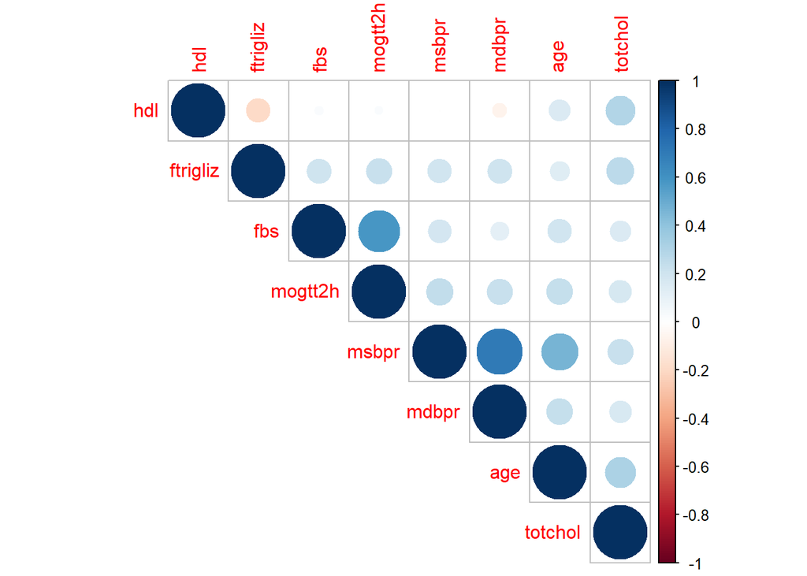

```r
corrplot(corr, type = 'upper', order = 'hclust')
```

FBS and GTT might be strongly correlated because both are measures of blood glucose levels. If these two predictors are highly correlated, it can lead to multicollinearity. so does SBP and DBP

lets see the **baseline differences** between the group DM vs non-DM

```r
diabetes %>%
  tbl_summary(
    by = dmdx,  # compare across DM status
    include = c(age, gender, bmi, totchol, crural),
    statistic = list(all_continuous() ~ "{mean} ({sd})"),
    digits = all_continuous() ~ 2,
  ) %>%
  modify_header(label ~ "**Variable**") %>%
  bold_labels()
```

| **Variable** | **no** N = 3,363<sup>1</sup> | **yes** N = 457<sup>1</sup> |
| --- | --- | --- |
| reported age (years) | 46.74 (14.46) | 56.63 (11.15) |
| gender |  |  |
| female | 2,219 (66%) | 278 (61%) |
| male | 1,144 (34%) | 179 (39%) |
| BMI | 25.46 (4.78) | 27.37 (4.81) |
| total cholesterol (mmol/l) | 5.75 (1.20) | 5.94 (1.30) |
| rural=1 urban=0 |  |  |
| urban | 1,753 (52%) | 248 (54%) |
| rural | 1,610 (48%) | 209 (46%) |

<sup>1</sup> Mean (SD); n (%)

The baseline differences between the two groupsmust be comparable to ensure that any observed differences in the outcome variable can be attributed to the risk factors, rather than being confounded by pre-existing differences.

## Estimate

### Univariable Analysis

Lets do univariable analysis first:

- **Identify variables** that have a significant association with the outcome when considered **individually**. This is useful before building a multivariable model.
- When the **effect size (e.g., odds ratio)** changes between univariable and multivariable logistic regression — either stronger or weaker — it gives insight into how the predictor interacts with other variables.

  –> The reduced effect size suggests that the association between [predictor] and diabetes is confounded by other variables such as [confounder/mediator]

  –> The stronger effect in the multivariable model suggests a suppression effect, where adjusting for [suppressor variable] revealed a stronger true association between [predictor] and diabetes

**univariable analysis : DV=dm (Yes/No), Covariate=age**

```r
uv.age <- glm(dmdx ~ age, family = binomial(link = 'logit'),
                  data = diabetes)
summary(uv.age)
```

```
Call:
glm(formula = dmdx ~ age, family = binomial(link = "logit"),
    data = diabetes)

Coefficients:
             Estimate Std. Error z value Pr(>|z|)
(Intercept) -4.642893   0.219626  -21.14   <2e-16 ***
age          0.051116   0.003863   13.23   <2e-16 ***
---
Signif. codes:  0 '***' 0.001 '**' 0.01 '*' 0.05 '.' 0.1 ' ' 1

(Dispersion parameter for binomial family taken to be 1)

    Null deviance: 2797.7  on 3819  degrees of freedom
Residual deviance: 2602.0  on 3818  degrees of freedom
AIC: 2606

Number of Fisher Scoring iterations: 5
```

**understanding the output:**

**Coefficients:** Each predictor’s **Estimate** tells you how much the log-odds of the outcome change for a one-unit increase in that predictor, assuming all other variables are held constant.

- It gives the baseline log-odds for the model.The intercept represents the log-odds of the outcome when all independent variables are zero.
- Each predictor’s **Estimate** tells you how much the log-odds of the outcome change for a one-unit increase in that predictor, assuming all other variables are held constant. E.g. As age increases by 1 year, the log odds of the outcome increase by about 0.051
- p-value indicates that the significance of the predictor

**Null deviance**: This is the deviance of the model that includes no predictors, i.e., just the intercept. It represents the goodness-of-fit for a model with no predictors.

**Residual deviance**: This is the deviance of the model with age included as a predictor. A reduction in deviance from the null deviance indicates that the model with age as a predictor fits the data better than the null model.

**AIC (Akaike Information Criterion)**: The AIC value is used to compare models. A lower AIC indicates a better-fitting model, taking both model fit and complexity into account.

**Degree of freedom:** the number of observationsminus the number of parameters being estimated.

Lets do for another independent variable

**univariable analysis : DV=dm (Yes/No), IDV=gender (female=0, male=1)**

```r
uv.gen <- glm(dmdx ~ gender, family = binomial(link = 'logit'),
                  data = diabetes)
summary(uv.gen)
```

```
Call:
glm(formula = dmdx ~ gender, family = binomial(link = "logit"),
    data = diabetes)

Coefficients:
            Estimate Std. Error z value Pr(>|z|)
(Intercept) -2.07719    0.06362 -32.650   <2e-16 ***
gendermale   0.22229    0.10251   2.168   0.0301 *
---
Signif. codes:  0 '***' 0.001 '**' 0.01 '*' 0.05 '.' 0.1 ' ' 1

(Dispersion parameter for binomial family taken to be 1)

    Null deviance: 2797.7  on 3819  degrees of freedom
Residual deviance: 2793.1  on 3818  degrees of freedom
AIC: 2797.1

Number of Fisher Scoring iterations: 4
```

or, you can run the analysis for all predictors at once

```r
uv_model <- tbl_uvregression(
    diabetes,
    method = glm,
    y = dmdx,
    method.args = list(family = binomial),
    exponentiate = TRUE, # to get the odds ratio
    include = c("age", "gender", "bmi", "totchol")
  )
uv_model
```

| **Characteristic** | **N** | **OR** | **95% CI** | **p-value** |
| --- | --- | --- | --- | --- |
| reported age (years) | 3,820 | 1.05 | 1.04, 1.06 | <0.001 |
| gender | 3,820 |  |  |  |
| female |  | — | — |  |
| male |  | 1.25 | 1.02, 1.53 | 0.030 |
| BMI | 3,820 | 1.08 | 1.06, 1.10 | <0.001 |
| total cholesterol (mmol/l) | 3,820 | 1.14 | 1.05, 1.23 | 0.001 |

Abbreviations: CI = Confidence Interval, OR = Odds Ratio

### Multivariable analysis

select the variables to be included in the multivariable model:

- Priori knowledge, literature review, Directed Acyclic Graph
- Clinical significance
- Statistical significance
- Automatic selection - backward/forward
- Avoid Collinearity - Highly correlated predictors should not both be included

Lets build a model with these risk factors: **age, gender, bmi, totchol**

multivariable analysis: DM ~ age+gender+ bmi+totchol

```r
mlog1 <- glm(dmdx ~ age + gender + bmi +totchol,
                      family = binomial(link = 'logit'),
                      data = diabetes)
summary(mlog1)
```

```
Call:
glm(formula = dmdx ~ age + gender + bmi + totchol, family = binomial(link = "logit"),
    data = diabetes)

Coefficients:
             Estimate Std. Error z value Pr(>|z|)
(Intercept) -7.403370   0.465845 -15.892   <2e-16 ***
age          0.055743   0.004192  13.298   <2e-16 ***
gendermale   0.238182   0.108194   2.201   0.0277 *
bmi          0.096084   0.010920   8.799   <2e-16 ***
totchol     -0.020537   0.043418  -0.473   0.6362
---
Signif. codes:  0 '***' 0.001 '**' 0.01 '*' 0.05 '.' 0.1 ' ' 1

(Dispersion parameter for binomial family taken to be 1)

    Null deviance: 2797.7  on 3819  degrees of freedom
Residual deviance: 2522.4  on 3815  degrees of freedom
AIC: 2532.4

Number of Fisher Scoring iterations: 5
```

Lets summarize the output and get the Odd Ratios

```r
mlog1_t <- tbl_regression(mlog1, exponentiate = TRUE)
mlog1_t
```

| **Characteristic** | **OR** | **95% CI** | **p-value** |
| --- | --- | --- | --- |
| reported age (years) | 1.06 | 1.05, 1.07 | <0.001 |
| gender |  |  |  |
| female | — | — |  |
| male | 1.27 | 1.03, 1.57 | 0.028 |
| BMI | 1.10 | 1.08, 1.12 | <0.001 |
| total cholesterol (mmol/l) | 0.98 | 0.90, 1.07 | 0.6 |

Abbreviations: CI = Confidence Interval, OR = Odds Ratio

Lets compare with the previous simple logistic regression model

```r
tbl_merge(
  list(uv_model, mlog1_t),  # List of models to merge
  tab_spanner = c("SlogR", "MlogR")  # Column headers for univariable and multivariable models
)
```

| **Characteristic** | SlogR **N** | SlogR **OR** | SlogR **95% CI** | SlogR **p-value** | MlogR **OR** | MlogR **95% CI** | MlogR **p-value** |
| --- | --- | --- | --- | --- | --- | --- | --- |
| reported age (years) | 3,820 | 1.05 | 1.04, 1.06 | <0.001 | 1.06 | 1.05, 1.07 | <0.001 |
| gender | 3,820 |  |  |  |  |  |  |
| female |  | — | — |  | — | — |  |
| male |  | 1.25 | 1.02, 1.53 | 0.030 | 1.27 | 1.03, 1.57 | 0.028 |
| BMI | 3,820 | 1.08 | 1.06, 1.10 | <0.001 | 1.10 | 1.08, 1.12 | <0.001 |
| total cholesterol (mmol/l) | 3,820 | 1.14 | 1.05, 1.23 | 0.001 | 0.98 | 0.90, 1.07 | 0.6 |

Abbreviations: CI = Confidence Interval, OR = Odds Ratio

The odds of having diabetes increase by 6% for each additional year of age (OR = 1.06, 95% CI: 1.05–1.07, p-value <0.001), after adjusting for **gender**, **BMI**, and **total cholesterol**.

After adjusting for **age**, **BMI**, and **total cholesterol**, males still have 27% higher odds of having diabetes compared to females (OR = 1.27, 95% CI: 1.03–1.57, p-value = 0.028).

After adjusting for **age**, **gender**, and **total colesterol**, each 1-unit increase in BMI is associated with a 10% higher odds of having diabetes (OR = 1.10, 95% CI: 1.08–1.12, p-value <0.001)

- BMI influences both total cholesterol levels and the risk of diabetes, individuals with higher body mass may also have higher cholesterol levels. When controlling for BMI, its effect on diabetes risk may diminish the significance of total cholesterol due to **confounding**. The OR changed by >10% (1.14 -> 0.98 ~ 14%).
- BMI and total cholesterol may be **correlated**.

Lets check for **multicollinearity**

```r
vif(mlog1)
```

```
     age   gender      bmi  totchol
1.074718 1.026503 1.058717 1.031907
```

A VIF value near **1** indicates **no multicollinearity.**

A VIF above **5** **- 10** indicates a potential issue with multicollinearity

### Interaction

Interaction may occurs when the effect of one variable on the outcome changes depending on the level of another variable.

For example, the relationship between age and diabetes risk might differ for men and women. As age increases, the odds of diabetes may increase at a faster rate in females than in males, e.g. due to hormonal changes during menopause.

Lets examine if the interaction term between age and gender is significant or not.

**multivariable analysis with interaction: DM ~ age+gender+bmi+ totchol + age*gender**

```r
mlog1.in <- glm(dmdx ~ age + gender + bmi + totchol + age:gender,
                      family = binomial(link = 'logit'),
                      data = diabetes)
summary(mlog1.in)
```

```
Call:
glm(formula = dmdx ~ age + gender + bmi + totchol + age:gender,
    family = binomial(link = "logit"), data = diabetes)

Coefficients:
                Estimate Std. Error z value Pr(>|z|)
(Intercept)    -7.240163   0.490413 -14.763   <2e-16 ***
age             0.052300   0.005380   9.721   <2e-16 ***
gendermale     -0.233741   0.482566  -0.484    0.628
bmi             0.095961   0.010917   8.790   <2e-16 ***
totchol        -0.015949   0.043668  -0.365    0.715
age:gendermale  0.008445   0.008397   1.006    0.315
---
Signif. codes:  0 '***' 0.001 '**' 0.01 '*' 0.05 '.' 0.1 ' ' 1

(Dispersion parameter for binomial family taken to be 1)

    Null deviance: 2797.7  on 3819  degrees of freedom
Residual deviance: 2521.4  on 3814  degrees of freedom
AIC: 2533.4

Number of Fisher Scoring iterations: 5
```

There is **no significant interaction** between age and gender in predicting the odds of diabetes. In other words, the effect of age on diabetes risk is not different for males and females.

### Model comparison

Which model is better? with or without interaction terms?

```r
anova(mlog1, mlog1.in, test = "Chisq")
```

```
Analysis of Deviance Table

Model 1: dmdx ~ age + gender + bmi + totchol
Model 2: dmdx ~ age + gender + bmi + totchol + age:gender
  Resid. Df Resid. Dev Df Deviance Pr(>Chi)
1      3815     2522.4
2      3814     2521.4  1    1.019   0.3127
```

Based on the analysis of deviance, the inclusion of the interaction term between age and gender in Model 2 **did not significantly** improve the model fit (p-value = 0.3127) Therefore, the **simpler model** (Model 1) without the interaction term is preferred for predicting the odds of diabetes.

## Inference (adding CI)

**final model: DM ~ age+gender+ bmi + totchol**

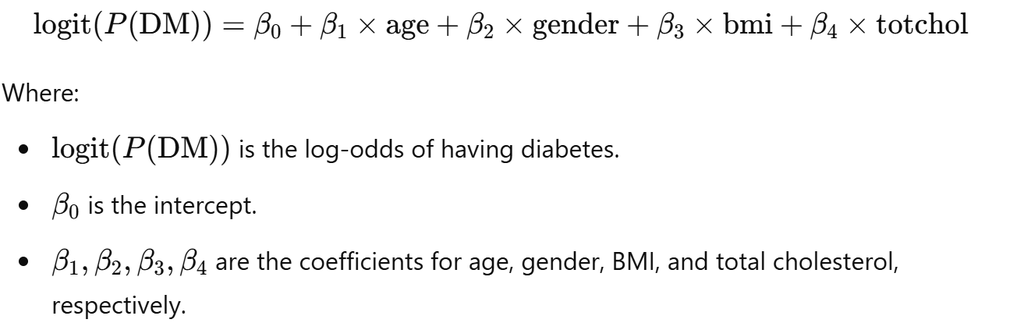

lets obtain the coefficient and 95% CI for the log odds

```r
tbl_regression(mlog1)
```

| **Characteristic** | **log(OR)** | **95% CI** | **p-value** |
| --- | --- | --- | --- |
| reported age (years) | 0.06 | 0.05, 0.06 | <0.001 |
| gender |  |  |  |
| female | — | — |  |
| male | 0.24 | 0.03, 0.45 | 0.028 |
| BMI | 0.10 | 0.07, 0.12 | <0.001 |
| total cholesterol (mmol/l) | -0.02 | -0.11, 0.06 | 0.6 |

Abbreviations: CI = Confidence Interval, OR = Odds Ratio

equation:

[figure not shown]

or, you can use the tidy function to get the coefficients and 95% CI for the coefficients

```r
mlog1_or<- tidy(mlog1,
                    exponentiate = TRUE, # to get the OR, remove for log odds
                    conf.int = T)
mlog1_or
```

```
# A tibble: 5 × 7
  term        estimate std.error statistic  p.value conf.low conf.high
  <chr>          <dbl>     <dbl>     <dbl>    <dbl>    <dbl>     <dbl>
1 (Intercept) 0.000609   0.466     -15.9   7.16e-57 0.000241   0.00150
2 age         1.06       0.00419    13.3   2.37e-40 1.05       1.07
3 gendermale  1.27       0.108       2.20  2.77e- 2 1.03       1.57
4 bmi         1.10       0.0109      8.80  1.38e-18 1.08       1.12
5 totchol     0.980      0.0434     -0.473 6.36e- 1 0.899      1.07
```

## Prediction

types of prediction

- “Link”: Predictions on the scale of the link function (log-odds for logistic regression).
- “Response”: Predictions on the scale of the response variable (probabilities for logistic regression).
- “Terms”: Contributions of each predictor variable to the linear prediction

### log odds

```r
predict_logodd <- augment(mlog1, type.predict = 'link')
predict_logodd
```

```
# A tibble: 3,820 × 11
   dmdx    age gender   bmi totchol .fitted .resid     .hat .sigma     .cooksd
   <fct> <dbl> <fct>  <dbl>   <dbl>   <dbl>  <dbl>    <dbl>  <dbl>       <dbl>
 1 no       70 female  16.9    5.43   -1.99 -0.506 0.00217   0.813 0.0000594
 2 no       20 male    18.0    5.13   -4.42 -0.154 0.000504  0.813 0.00000121
 3 no       29 female  15.6    5.55   -4.40 -0.156 0.000455  0.813 0.00000112
 4 no       25 male    18.9    4.01   -4.04 -0.187 0.000641  0.813 0.00000226
 5 no       37 female  21.5    5.21   -3.39 -0.258 0.000519  0.813 0.00000351
 6 no       43 female  21.3    6.19   -3.08 -0.299 0.000545  0.813 0.00000500
 7 no       26 female  22.2    4.33   -3.91 -0.199 0.000518  0.813 0.00000208
 8 no       28 female  15.4    5.84   -4.48 -0.150 0.000443  0.813 0.00000100
 9 no       48 male    17.1    6.14   -2.97 -0.317 0.000923  0.813 0.00000951
10 no       20 female  17.1    6.02   -4.77 -0.130 0.000376  0.813 0.000000636
# ℹ 3,810 more rows
# ℹ 1 more variable: .std.resid <dbl>
```

### odds

odds ratio = exponentiate(log odds)

lets add a column for odds

```r
predict_odds <- predict_logodd %>%
  mutate(odds = exp(.fitted))
predict_odds
```

```
# A tibble: 3,820 × 12
   dmdx    age gender   bmi totchol .fitted .resid     .hat .sigma     .cooksd
   <fct> <dbl> <fct>  <dbl>   <dbl>   <dbl>  <dbl>    <dbl>  <dbl>       <dbl>
 1 no       70 female  16.9    5.43   -1.99 -0.506 0.00217   0.813 0.0000594
 2 no       20 male    18.0    5.13   -4.42 -0.154 0.000504  0.813 0.00000121
 3 no       29 female  15.6    5.55   -4.40 -0.156 0.000455  0.813 0.00000112
 4 no       25 male    18.9    4.01   -4.04 -0.187 0.000641  0.813 0.00000226
 5 no       37 female  21.5    5.21   -3.39 -0.258 0.000519  0.813 0.00000351
 6 no       43 female  21.3    6.19   -3.08 -0.299 0.000545  0.813 0.00000500
 7 no       26 female  22.2    4.33   -3.91 -0.199 0.000518  0.813 0.00000208
 8 no       28 female  15.4    5.84   -4.48 -0.150 0.000443  0.813 0.00000100
 9 no       48 male    17.1    6.14   -2.97 -0.317 0.000923  0.813 0.00000951
10 no       20 female  17.1    6.02   -4.77 -0.130 0.000376  0.813 0.000000636
# ℹ 3,810 more rows
# ℹ 2 more variables: .std.resid <dbl>, odds <dbl>
```

### probability

Lets get the predicted probability for each observation

```r
predict_prob <-augment(mlog1, type.predict = 'response', se.fit = TRUE)
predict_prob
```

```
# A tibble: 3,820 × 11
   dmdx    age gender   bmi totchol .fitted .resid     .hat .sigma     .cooksd
   <fct> <dbl> <fct>  <dbl>   <dbl>   <dbl>  <dbl>    <dbl>  <dbl>       <dbl>
 1 no       70 female  16.9    5.43 0.120   -0.506 0.00217   0.813 0.0000594
 2 no       20 male    18.0    5.13 0.0119  -0.154 0.000504  0.813 0.00000121
 3 no       29 female  15.6    5.55 0.0121  -0.156 0.000455  0.813 0.00000112
 4 no       25 male    18.9    4.01 0.0173  -0.187 0.000641  0.813 0.00000226
 5 no       37 female  21.5    5.21 0.0327  -0.258 0.000519  0.813 0.00000351
 6 no       43 female  21.3    6.19 0.0438  -0.299 0.000545  0.813 0.00000500
 7 no       26 female  22.2    4.33 0.0197  -0.199 0.000518  0.813 0.00000208
 8 no       28 female  15.4    5.84 0.0112  -0.150 0.000443  0.813 0.00000100
 9 no       48 male    17.1    6.14 0.0489  -0.317 0.000923  0.813 0.00000951
10 no       20 female  17.1    6.02 0.00839 -0.130 0.000376  0.813 0.000000636
# ℹ 3,810 more rows
# ℹ 1 more variable: .std.resid <dbl>
```

Lets visualize the probabilities (age)

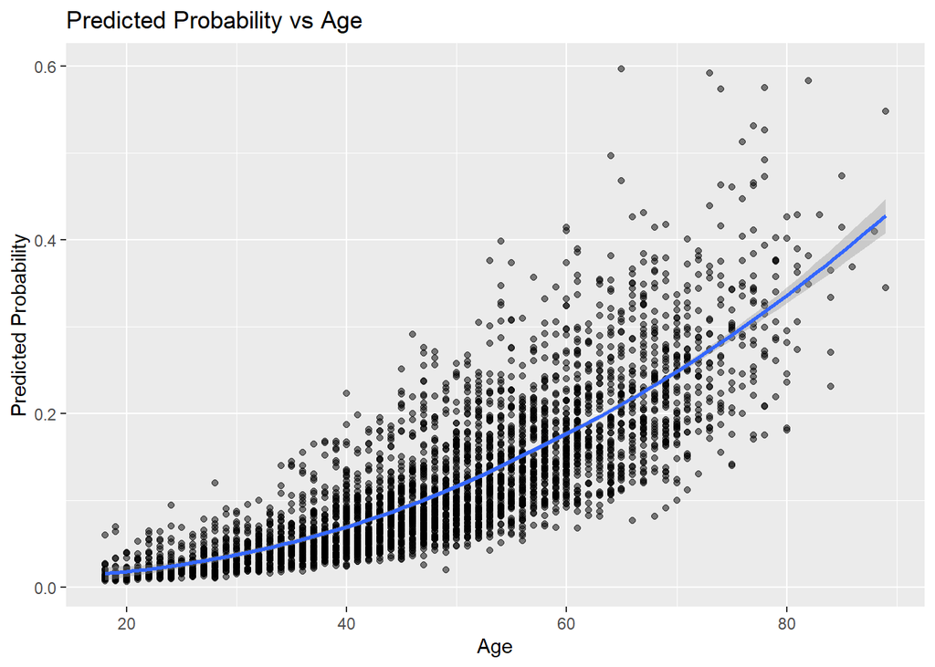

```r
ggplot(predict_prob, aes(x = age, y = .fitted)) +
  geom_point(alpha = 0.5) +
  geom_smooth(method = "loess") +
  labs(title = "Predicted Probability vs Age",
       x = "Age", y = "Predicted Probability")
```

or you can visualize gender-specific probabilities

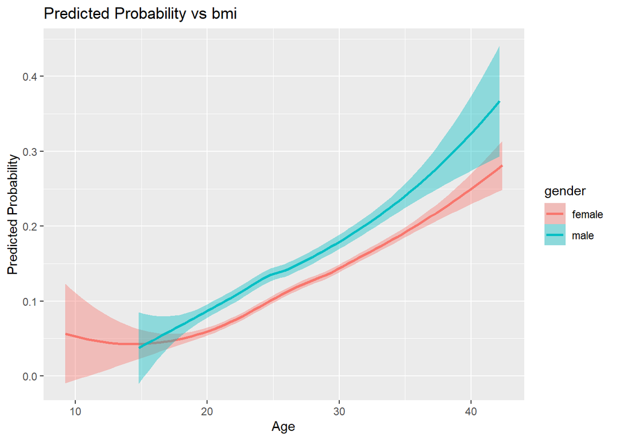

```r
ggplot(predict_prob, aes(x = bmi, y = .fitted, color = gender, fill = gender)) +
  geom_smooth(method = "loess") +
  labs(title = "Predicted Probability vs bmi",
       x = "Age", y = "Predicted Probability")
```

### Predict new data

lets predict the **log odds** of being diabetic for a 70 year old male with BMI 38 and total cholesterol of 6 mmol/l

```r
newdata <- expand.grid(age = 70,
                         bmi = 38,
                         totchol = 6,
                         gender = 'male')

augment(mlog1,
        newdata = newdata,
        type.predict = 'link')
```

```
# A tibble: 1 × 5
    age   bmi totchol gender .fitted
  <dbl> <dbl>   <dbl> <fct>    <dbl>
1    70    38       6 male     0.265
```

predict the odds

```r
exp(0.2647592)
```

```
[1] 1.303117
```

predict the probability

```r
augment(mlog1,
        newdata = newdata,
        type.predict = 'response')
```

```
# A tibble: 1 × 5
    age   bmi totchol gender .fitted
  <dbl> <dbl>   <dbl> <fct>    <dbl>
1    70    38       6 male     0.566
```

There is a **56.6%** chance this individual has diabetes based on your model.

## Model Performance

lets evaluate the **confusion matrix and performance statistics** based on the model predictions:

```r
mlog1.prob <-
  augment(mlog1,
          type.predict = 'response') |>
  mutate(pred.class = factor(ifelse(.fitted > 0.5, 'yes', 'no')))


confusionMatrix(mlog1.prob$dmdx, mlog1.prob$pred.class)
```

```
Confusion Matrix and Statistics

          Reference
Prediction   no  yes
       no  3357    6
       yes  454    3

               Accuracy : 0.8796
                 95% CI : (0.8688, 0.8897)
    No Information Rate : 0.9976
    P-Value [Acc > NIR] : 1

                  Kappa : 0.0083

 Mcnemar's Test P-Value : <2e-16

            Sensitivity : 0.880871
            Specificity : 0.333333
         Pos Pred Value : 0.998216
         Neg Pred Value : 0.006565
             Prevalence : 0.997644
         Detection Rate : 0.878796
   Detection Prevalence : 0.880366
      Balanced Accuracy : 0.607102

       'Positive' Class : no
```

lets examine the ROC

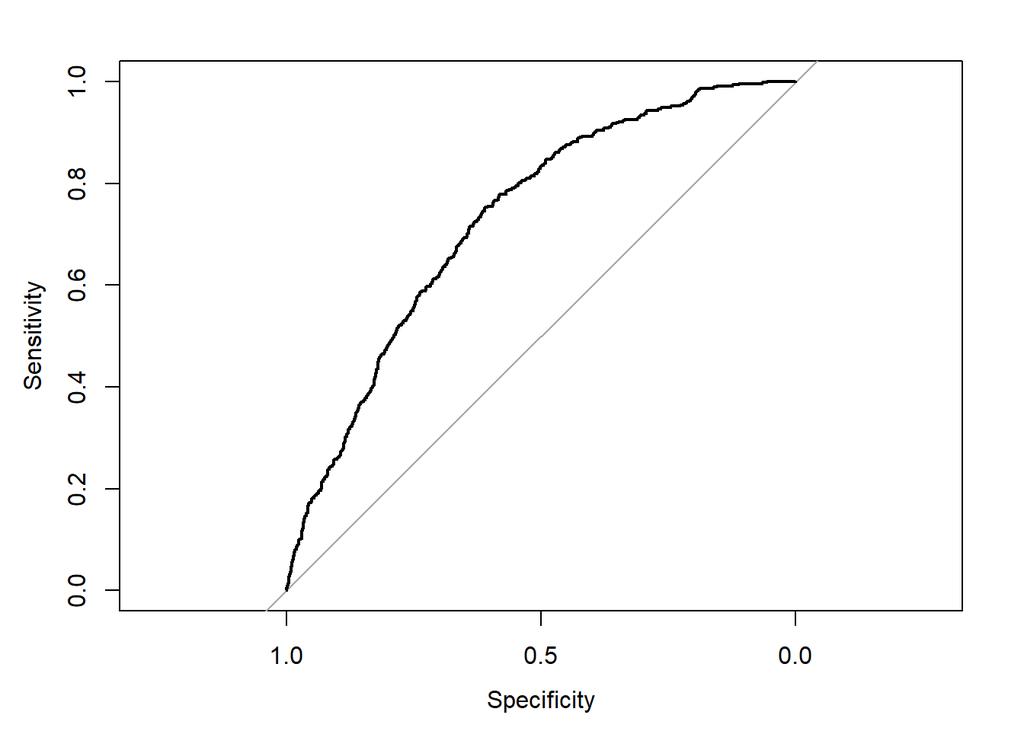

```r
y <-diabetes$dmdx
roc_obj <- roc(response = y, predictor = fitted(mlog1))
plot(roc_obj)
```

```r
auc(roc_obj)
```

```
Area under the curve: 0.7301
```

**AUROC** is >70%

lets perform the Hosmer Lemeshow test

```r
library(generalhoslem)
logitgof(diabetes$dmdx, fitted(mlog1), g = 10)
```

```
    Hosmer and Lemeshow test (binary model)

data:  diabetes$dmdx, fitted(mlog1)
X-squared = 15.091, df = 8, p-value = 0.0574
```

**p > 0.05** → Model **fits well** .

Lets check the assumptions too.

**Linearity in logit assumption**

The relationship between the continuous predictor variables and the log-odds (logit) of the outcome variable is linear. This means that for each unit increase in a continuous predictor, the log-odds of the outcome are predicted to change by a constant amount.

Lets test whether the relationship between continuous variables (age, BMI, and total cholesterol) and the risk of diabetes follows a straight-line pattern on the logit scale (log odds).

```r
lin.logit <-
  mfp(dmdx ~ fp(age) + fp(totchol) + fp(bmi) + gender,
      family = binomial(link = 'logit'),
      data = diabetes, verbose = T)
```

```
    Variable    Deviance    Power(s)
------------------------------------------------
Cycle 1
    age
                2720.36
                2522.396    1
                2501.685    -1
                2497.796    1 3

    bmi
                2568.316
                2501.685    1
                2500.172    -0.5
                2498.678    -2 3

    gendermale
                2507.189
                2501.685    1



    totchol
                2502.481
                2501.685    1
                2499.955    -2
                2497.781    0.5 3


Tansformation
           shift scale
age            0   100
bmi            0    10
gendermale     0     1
totchol        0    10

Fractional polynomials
           df.initial select alpha df.final power1 power2
age                 4      1  0.05        2     -1      .
bmi                 4      1  0.05        1      1      .
gendermale          1      1  0.05        1      1      .
totchol             4      1  0.05        1      1      .


Transformations of covariates:
                  formula
age       I((age/100)^-1)
totchol I((totchol/10)^1)
bmi         I((bmi/10)^1)
gender             gender


Deviance table:
         Resid. Dev
Null model   2797.723
Linear model     2522.396
Final model  2501.685
```

```r
summary(lin.logit)
```

```
Call:
glm(formula = dmdx ~ I((age/100)^-1) + I((bmi/10)^1) + gender +
    I((totchol/10)^1), family = binomial(link = "logit"), data = diabetes)

Coefficients:
                  Estimate Std. Error z value Pr(>|z|)
(Intercept)        -1.2852     0.4619  -2.783  0.00539 **
I((age/100)^-1)    -1.4348     0.1210 -11.859  < 2e-16 ***
I((bmi/10)^1)       0.8911     0.1094   8.144 3.81e-16 ***
gendermale          0.2549     0.1080   2.360  0.01829 *
I((totchol/10)^1)  -0.3893     0.4379  -0.889  0.37396
---
Signif. codes:  0 '***' 0.001 '**' 0.01 '*' 0.05 '.' 0.1 ' ' 1

(Dispersion parameter for binomial family taken to be 1)

    Null deviance: 2797.7  on 3819  degrees of freedom
Residual deviance: 2501.7  on 3815  degrees of freedom
AIC: 2511.7

Number of Fisher Scoring iterations: 6
```

While age is significant in the model, it has been transformed - indicates that **age is non-linearly related to the log odds of diabetes.** Non-linear relationship, so the linearity assumption is violated, but we’ve corrected this with a transformation.

The linear term for BMI was significant (p < 0.001), which means a **linear relationship** with the log odds is appropriate.

**Extreme outliers**

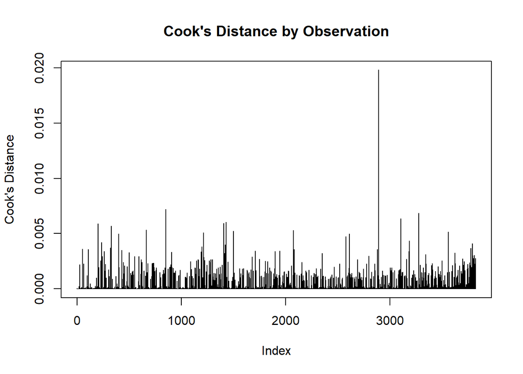

```r
cooks <- cooks.distance(mlog1)
plot(cooks, type = "h", ylab = "Cook's Distance", main = "Cook's Distance by Observation")
```

You can also computes the standardized residuals (`.std.resid`) and the Cook’s distance (`.cooksd`) using the R function `augment()` [broom package]. Data points with an absolute standardized residuals above 3 represent possible outliers and may deserve closer attention.

```r
mlog1_data <- augment(mlog1) %>%
  mutate(index = 1:n())
```

then, filter potential influential data points with standardized residuals > 3

```r
mlog1_data %>%
  filter(abs(.std.resid) > 3)
```

```
# A tibble: 0 × 12
# ℹ 12 variables: dmdx <fct>, age <dbl>, gender <fct>, bmi <dbl>,
#   totchol <dbl>, .fitted <dbl>, .resid <dbl>, .hat <dbl>, .sigma <dbl>,
#   .cooksd <dbl>, .std.resid <dbl>, index <int>
```

There is no influential observations in our data.

However, if you have influential outliers in your data, consider:

- **Remove Outliers**: Exclude extreme values if they’re errors or irrelevant, but be cautious of bias or data loss.
- **Transform Data**: Apply log or other transformations to reduce skewness and lessen the impact of outliers.
- **Use Robust Methods**: Opt for non-parametric or robust models (e.g., random forests, robust regression) that are less sensitive to outliers.

References

- https://www.sthda.com/english/articles/36-classification-methods-essentials/148-logistic-regression-assumptions-and-diagnostics-in-r/
- https://stats.oarc.ucla.edu/r/dae/logit-regression/
- Boehmke, B., & Greenwell, B. (2020). *Hands-On Machine Learning with R*. O’Reilly Media.
- Kleinbaum, D. G., Klein, M., Kleinbaum, D. G., & Klein, M. (2010). Introduction to logistic regression. *Logistic regression: a self-learning text*, 1-39.
- Zhang, Z. & Wang, L. (2017-2025). *Advanced statistics using R*. Granger, IN: ISDSA Press. https://doi.org/10.35566/advstats. ISBN: 978-1-946728-01-2.
- Kamarul Imran, Wan Nor Arifin, & Tengku Muhammad Hanis Tengku Mokhtar. (2024). *Data Analysis in Medicine and Health using R*. Retrieved from https://bookdown.org/drki_musa/dataanalysis/